# Biostatistical Computing, PHC 6068

Data manipulation (Tidyverse)

Zhiguang Huo (Caleb)

Wednesday September 19, 2018

# Outline

The tidyverse is a collection of R packages designed for data science.

- ggplot2
- readr
- dplyr
- tidyr

```r
library(readr)
library(dplyr)
```

```r
library(tidyr)
library(ggplot2)
## alternatively, you can do library(tidyverse) to include all of them
```

# Read in data (readr)

- data source: sleepstudy.csv (also available in R lme4 package)
- Original way to read in data

```r
asleepfile <- "https://raw.githubusercontent.com/Caleb-Huo/Caleb-Huo.github.io/master/teaching/data/sleep/sleepstudy.csv"
data0 <- read.csv(asleepfile)
```

- Use read_csv
  - Much faster than read.csv, especially for large datasets

```r
data1 <- read_csv(asleepfile)
```

# Inspect the data

- read.csv
  - You may want to use head, otherwise it will print out everyting

```r
head(data0)
```

```
##   Reaction Days Subject
## 1 249.5600    0     308
## 2 258.7047    1     308
## 3 250.8006    2     308
## 4 321.4398    3     308
## 5 356.8519    4     308
## 6 414.6901    5     308
```

```r
class(data0)
```

```
## [1] "data.frame"
```

- read_csv
  - smartly print out the first few rows

```r
data1
```

```
## # A tibble: 180 x 3
##    Reaction  Days Subject
##       <dbl> <int>   <int>
##  1     250.     0     308
##  2     259.     1     308
##  3     251.     2     308
##  4     321.     3     308
##  5     357.     4     308
##  6     415.     5     308
##  7     382.     6     308
##  8     290.     7     308
##  9     431.     8     308
## 10     466.     9     308
## # ... with 170 more rows
```

```r
class(data1)
```

```
## [1] "tbl_df"     "tbl"        "data.frame"
```

# read_delim

- Similar to read_csv, we can use read_delim, which is more general
  - read_csv assumes the delimiter is “,”
  - for read_delim, you need to specify the delimiter
    - “,”: comma delimited (usually for .csv)
    - “\t”: tab delimited (usually for .txt)
    - " “: space delimited

```r
data2 <- read_delim("sleepstudy.csv", delim=",")
```

# Play with data1

```r
data1_sub <- data1[1:3,]
data1_sub$Reaction
```

```
## [1] 249.5600 258.7047 250.8006
```

```r
as.matrix(data1_sub)
```

```
##      Reaction Days Subject
## [1,] 249.5600    0     308
## [2,] 258.7047    1     308
## [3,] 250.8006    2     308
```

```r
as.data.frame(data1_sub)
```

```
##   Reaction Days Subject
## 1 249.5600    0     308
## 2 258.7047    1     308
## 3 250.8006    2     308
```

# dplyr

- %>%: pipe
- select(): select columns
- filter(): filter rows
- arrange(): re-order or arrange rows
- mutate(): create new columns
- summarise(): summarise values
- group_by(): allows for group operations in the “split-apply-combine” concept
- merge data.frame
  - inner_join()
  - left_join()
  - right_join()
  - full_join()
  - anti_join()

# select

```r
select(data1, Days, Subject)
```

```
## # A tibble: 180 x 2
##     Days Subject
##    <int>   <int>
##  1     0     308
##  2     1     308
##  3     2     308
##  4     3     308
##  5     4     308
##  6     5     308
##  7     6     308
##  8     7     308
##  9     8     308
## 10     9     308
## # ... with 170 more rows
```

- Use pipe

```r
data1 %>% select(Days, Subject)
```

```
## # A tibble: 180 x 2
##     Days Subject
##    <int>   <int>
##  1     0     308
##  2     1     308
##  3     2     308
##  4     3     308
##  5     4     308
##  6     5     308
##  7     6     308
##  8     7     308
##  9     8     308
## 10     9     308
## # ... with 170 more rows
```

# pipe

- %>%
- data1 %>% select(Days, Subject)
  - the result before %>% will be piped into the first argument of the function behind %>%
- Do not select

```r
data1 %>% select(-Reaction)
```

```
## # A tibble: 180 x 2
##     Days Subject
##    <int>   <int>
##  1     0     308
##  2     1     308
##  3     2     308
##  4     3     308
##  5     4     308
##  6     5     308
##  7     6     308
##  8     7     308
##  9     8     308
## 10     9     308
## # ... with 170 more rows
```

# filter

```r
data1 %>%
  select(Days, Subject) %>%
  filter(Subject == 308)
```

```
## # A tibble: 10 x 2
##     Days Subject
##    <int>   <int>
##  1     0     308
##  2     1     308
##  3     2     308
##  4     3     308
##  5     4     308
##  6     5     308
##  7     6     308
##  8     7     308
##  9     8     308
## 10     9     308
```

```r
data1 %>%
  filter(Reaction >= 300) %>%
  select(Days, Subject) %>%
  filter(Subject == 308)
```

```
## # A tibble: 6 x 2
##    Days Subject
##   <int>   <int>
## 1     3     308
## 2     4     308
## 3     5     308
## 4     6     308
## 5     8     308
## 6     9     308
```

- multiple filtering criteria

```r
data1 %>%
  filter(Reaction >= 300, Subject == 308)
```

```
## # A tibble: 6 x 3
##   Reaction  Days Subject
##      <dbl> <int>   <int>
## 1     321.     3     308
## 2     357.     4     308
## 3     415.     5     308
## 4     382.     6     308
## 5     431.     8     308
## 6     466.     9     308
```

# arrange

- arrange() is similar to sort() and order()
- assending order by default

```r
data1 %>% arrange(Reaction) %>% head
```

```
## # A tibble: 6 x 3
##   Reaction  Days Subject
##      <dbl> <int>   <int>
## 1     194.     1     310
## 2     199.     0     310
## 3     203.     2     309
## 4     205.     3     309
## 5     205.     1     309
## 6     208.     4     309
```

```r
data1 %>%
  arrange(Days, Reaction) %>%
  head
```

```
## # A tibble: 6 x 3
##   Reaction  Days Subject
##      <dbl> <int>   <int>
## 1     199.     0     310
## 2     222.     0     352
## 3     223.     0     309
## 4     225.     0     370
## 5     235.     0     332
## 6     236.     0     349
```

```r
data1 %>%
  arrange(desc(Days), Reaction) %>%
  head
```

```
## # A tibble: 6 x 3
##   Reaction  Days Subject
##      <dbl> <int>   <int>
## 1     237.     9     335
## 2     237.     9     309
## 3     248.     9     310
## 4     254.     9     332
## 5     348.     9     351
## 6     352.     9     349
```

# mutate

```r
data1 %>%
  mutate(Reaction_binary = Reaction<250) %>%
  head
```

```
## # A tibble: 6 x 4
##   Reaction  Days Subject Reaction_binary
##      <dbl> <int>   <int> <lgl>
## 1     250.     0     308 TRUE
## 2     259.     1     308 FALSE
## 3     251.     2     308 FALSE
## 4     321.     3     308 FALSE
## 5     357.     4     308 FALSE
## 6     415.     5     308 FALSE
```

```r
data1 %>%
  mutate(Reaction_binary = Reaction<250) %>%
  mutate(Reaction_sec = Reaction/1000) %>%
  head
```

```
## # A tibble: 6 x 5
##   Reaction  Days Subject Reaction_binary Reaction_sec
##      <dbl> <int>   <int> <lgl>                  <dbl>
## 1     250.     0     308 TRUE                   0.250
## 2     259.     1     308 FALSE                  0.259
## 3     251.     2     308 FALSE                  0.251
## 4     321.     3     308 FALSE                  0.321
## 5     357.     4     308 FALSE                  0.357
## 6     415.     5     308 FALSE                  0.415
```

# summarise

```r
data1 %>%
    summarise(avg_reaction = mean(Reaction),
              min_reaction = min(Reaction),
              max_reaction = max(Reaction),
              total = n())
```

```
## # A tibble: 1 x 4
##   avg_reaction min_reaction max_reaction total
##          <dbl>        <dbl>        <dbl> <int>
## 1         299.         194.         466.   180
```

# group_by

- seems to be more powerful than tapply

```r
tt <- data1 %>%
      group_by(Subject) %>%
      summarise(avg_reaction = mean(Reaction),
              min_reaction = min(Reaction),
              max_reaction = max(Reaction),
              total = n())
tt %>% head
```

```
## # A tibble: 6 x 5
##   Subject avg_reaction min_reaction max_reaction total
##     <int>        <dbl>        <dbl>        <dbl> <int>
## 1     308         342.         250.         466.    10
## 2     309         215.         203.         237.    10
## 3     310         231.         194.         261.    10
## 4     330         303.         280.         354.    10
## 5     331         309.         285          372.    10
## 6     332         307.         235.         454.    10
```

# select (2)

- Select a range

```r
tt %>%
  head %>%
  select(avg_reaction:max_reaction)
```

```
## # A tibble: 6 x 3
##   avg_reaction min_reaction max_reaction
##          <dbl>        <dbl>        <dbl>
## 1         342.         250.         466.
## 2         215.         203.         237.
## 3         231.         194.         261.
## 4         303.         280.         354.
## 5         309.         285          372.
## 6         307.         235.         454.
```

- contains

```r
tt %>%
  head %>%
  select(contains("reaction"))
```

```
## # A tibble: 6 x 3
##   avg_reaction min_reaction max_reaction
##          <dbl>        <dbl>        <dbl>
## 1         342.         250.         466.
## 2         215.         203.         237.
## 3         231.         194.         261.
## 4         303.         280.         354.
## 5         309.         285          372.
## 6         307.         235.         454.
```

# more options for select()

- starts_with() = Select columns that start with a character string
- ends_with() = Select columns that end with a character string
- contains() = Select columns that contain a character string
- matches() = Select columns that match a regular expression
- one_of() = Select columns names that are from a group of names

# merge data.frame

- inner_join()
- left_join()
- right_join()
- full_join()
- anti_join()

# the data for merge

```r
superheroes <- "
    name, alignment, gender,         publisher
 Magneto,       bad,   male,            Marvel
   Storm,      good, female,            Marvel
Mystique,       bad, female,            Marvel
  Batman,      good,   male,                DC
   Joker,       bad,   male,                DC
Catwoman,       bad, female,                DC
 Hellboy,      good,   male, Dark Horse Comics
"
superheroes <- read_csv(superheroes, skip = 1)

publishers <- "
  publisher, yr_founded
         DC,       1934
     Marvel,       1939
      Image,       1992
"
publishers <- read_csv(publishers, skip = 1)
```

# inner_join

- inner_join(x, y): Return all rows from x where there are matching values in y, and all columns from x and y.
- If there are multiple matches between x and y, all combination of the matches are returned.
- This is a mutating join.

```r
inner_join(superheroes, publishers)
```

```
## # A tibble: 6 x 5
##   name     alignment gender publisher yr_founded
##   <chr>    <chr>     <chr>  <chr>          <int>
## 1 Magneto  bad       male   Marvel          1939
## 2 Storm    good      female Marvel          1939
## 3 Mystique bad       female Marvel          1939
## 4 Batman   good      male   DC              1934
## 5 Joker    bad       male   DC              1934
## 6 Catwoman bad       female DC              1934
```

```r
inner_join(publishers, superheroes)
```

```
## # A tibble: 6 x 5
##   publisher yr_founded name     alignment gender
##   <chr>          <int> <chr>    <chr>     <chr>
## 1 DC              1934 Batman   good      male
## 2 DC              1934 Joker    bad       male
## 3 DC              1934 Catwoman bad       female
## 4 Marvel          1939 Magneto  bad       male
## 5 Marvel          1939 Storm    good      female
## 6 Marvel          1939 Mystique bad       female
```

# left_join

- left_join(x, y): Return all rows from x, and all columns from x and y.
- If there are multiple matches between x and y, all combination of the matches are returned.
- This is a mutating join

```r
left_join(superheroes, publishers)
```

```
## # A tibble: 7 x 5
##   name     alignment gender publisher         yr_founded
##   <chr>    <chr>     <chr>  <chr>                  <int>
## 1 Magneto  bad       male   Marvel                  1939
## 2 Storm    good      female Marvel                  1939
## 3 Mystique bad       female Marvel                  1939
## 4 Batman   good      male   DC                      1934
## 5 Joker    bad       male   DC                      1934
## 6 Catwoman bad       female DC                      1934
## 7 Hellboy  good      male   Dark Horse Comics         NA
```

```r
left_join(publishers, superheroes)
```

```
## # A tibble: 7 x 5
##   publisher yr_founded name     alignment gender
##   <chr>          <int> <chr>    <chr>     <chr>
## 1 DC              1934 Batman   good      male
## 2 DC              1934 Joker    bad       male
## 3 DC              1934 Catwoman bad       female
## 4 Marvel          1939 Magneto  bad       male
## 5 Marvel          1939 Storm    good      female
## 6 Marvel          1939 Mystique bad       female
## 7 Image           1992 <NA>     <NA>      <NA>
```

# right_join

- right_join(x, y): Return all rows from y, and all columns from x and y.
- If there are multiple matches between x and y, all combination of the matches are returned.
- This is a mutating join

```r
right_join(superheroes, publishers)
```

```
## # A tibble: 7 x 5
##   name     alignment gender publisher yr_founded
##   <chr>    <chr>     <chr>  <chr>          <int>
## 1 Batman   good      male   DC              1934
## 2 Joker    bad       male   DC              1934
## 3 Catwoman bad       female DC              1934
## 4 Magneto  bad       male   Marvel          1939
## 5 Storm    good      female Marvel          1939
## 6 Mystique bad       female Marvel          1939
## 7 <NA>     <NA>      <NA>   Image           1992
```

```r
right_join(publishers, superheroes)
```

```
## # A tibble: 7 x 5
##   publisher         yr_founded name     alignment gender
##   <chr>                  <int> <chr>    <chr>     <chr>
## 1 Marvel                  1939 Magneto  bad       male
## 2 Marvel                  1939 Storm    good      female
## 3 Marvel                  1939 Mystique bad       female
## 4 DC                      1934 Batman   good      male
## 5 DC                      1934 Joker    bad       male
## 6 DC                      1934 Catwoman bad       female
## 7 Dark Horse Comics         NA Hellboy  good      male
```

# anti_join

- anti_join(x, y): Return all rows from x where there are not matching values in y, keeping just columns from x.
- This is a filtering join.

```r
anti_join(superheroes, publishers)
```

```
## # A tibble: 1 x 4
##   name    alignment gender publisher
##   <chr>   <chr>     <chr>  <chr>
## 1 Hellboy good      male   Dark Horse Comics
```

```r
anti_join(publishers, superheroes)
```

```
## # A tibble: 1 x 2
##   publisher yr_founded
##   <chr>          <int>
## 1 Image           1992
```

# full_join

- full_join(x, y): Return all rows and all columns from both x and y.
- Where there are not matching values, returns NA for the one missing.
- This is a mutating join.

```r
full_join(superheroes, publishers)
```

```
## # A tibble: 8 x 5
##   name     alignment gender publisher         yr_founded
##   <chr>    <chr>     <chr>  <chr>                  <int>
## 1 Magneto  bad       male   Marvel                  1939
## 2 Storm    good      female Marvel                  1939
## 3 Mystique bad       female Marvel                  1939
## 4 Batman   good      male   DC                      1934
## 5 Joker    bad       male   DC                      1934
## 6 Catwoman bad       female DC                      1934
## 7 Hellboy  good      male   Dark Horse Comics         NA
## 8 <NA>     <NA>      <NA>   Image                   1992
```

```r
full_join(publishers, superheroes)
```

```
## # A tibble: 8 x 5
##   publisher         yr_founded name     alignment gender
##   <chr>                  <int> <chr>    <chr>     <chr>
## 1 DC                      1934 Batman   good      male
## 2 DC                      1934 Joker    bad       male
## 3 DC                      1934 Catwoman bad       female
## 4 Marvel                  1939 Magneto  bad       male
## 5 Marvel                  1939 Storm    good      female
## 6 Marvel                  1939 Mystique bad       female
## 7 Image                   1992 <NA>     <NA>      <NA>
## 8 Dark Horse Comics         NA Hellboy  good      male
```

# tidyr

# spread

- Function:
  - spread(data, key, value, fill = NA, convert = FALSE)
- Same as:
  - data %>% spread(key, value, fill = NA, convert = FALSE)
- Arguments:
  - data: data frame
  - key: column values to convert to multiple columns
  - value: single column values to convert to multiple columns’ values
  - fill: If there isn’t a value for every combination of the other variables and the key column, this value will be substituted
  - convert: if TRUE will automatically convert values to logical, integer, numeric, complex or factor as appropriate

# spread example

```r
data1_wide <- data1 %>% spread(Days, Reaction, fill = NA, convert = FALSE)
head(data1_wide)
```

```
## # A tibble: 6 x 11
##   Subject   `0`   `1`   `2`   `3`   `4`   `5`   `6`   `7`   `8`   `9`
##     <int> <dbl> <dbl> <dbl> <dbl> <dbl> <dbl> <dbl> <dbl> <dbl> <dbl>
## 1     308  250.  259.  251.  321.  357.  415.  382.  290.  431.  466.
## 2     309  223.  205.  203.  205.  208.  216.  214.  218.  224.  237.
## 3     310  199.  194.  234.  233.  229.  220.  235.  256.  261.  248.
## 4     330  322.  300.  284.  285.  286.  298.  280.  318.  305.  354.
## 5     331  288.  285   302.  320.  316.  293.  290.  335.  294.  372.
## 6     332  235.  243.  273.  310.  317.  310.  454.  347.  330.  254.
```

# gather

- Function:
  - gather(data, key, value, …, na.rm = FALSE, convert = FALSE)
- Same as:
  - data %>% gather(key, value, …, na.rm = FALSE, convert = FALSE)
- Arguments:
  - data: data frame
  - key: column name representing new variable
  - value: column name representing variable values
  - …: names of columns to gather (or not gather)
  - na.rm: option to remove observations with missing values (represented by NAs)
  - convert: if TRUE will automatically convert values to logical, integer, numeric, complex or factor as appropriate

# gather example

```r
data1_long <- data1_wide %>% gather(ddays, rreaction, "0":"9")
head(data1_long)
```

```
## # A tibble: 6 x 3
##   Subject ddays rreaction
##     <int> <chr>     <dbl>
## 1     308 0          250.
## 2     309 0          223.
## 3     310 0          199.
## 4     330 0          322.
## 5     331 0          288.
## 6     332 0          235.
```

# unite

- Function:
  - unite(data, col, …, sep = " “, remove = TRUE)
- Same as:
  - data %>% unite(col, …, sep = " “, remove = TRUE)
- Arguments:
  - data: data frame
  - col: column name of new “merged” column
  - …: names of columns to merge
  - sep: separator to use between merged values
  - remove: if TRUE, remove input column from output data frame

# unite example

```r
data1_unite<- data1 %>% unite(Subject_Days, Subject, Days, sep="_")
head(data1_unite)
```

```
## # A tibble: 6 x 2
##   Reaction Subject_Days
##      <dbl> <chr>
## 1     250. 308_0
## 2     259. 308_1
## 3     251. 308_2
## 4     321. 308_3
## 5     357. 308_4
## 6     415. 308_5
```

# separate

- Function:
  - separate(data, col, into, sep = " “, remove = TRUE, convert = FALSE)
- Same as:
  - data %>% separate(col, into, sep = " “, remove = TRUE, convert = FALSE)
- Arguments:
  - data: data frame
  - col: column name representing current variable
  - into: names of variables representing new variables
  - sep: how to separate current variable (char, num, or symbol)
  - remove: if TRUE, remove input column from output data frame
  - convert: if TRUE will automatically convert values to logical, integer, numeric, complex or factor as appropriate

# separate example

```r
data1_separate<- data1_unite %>% separate(Subject_Days, c("subjects", "days"), sep="_")
head(data1_separate)
```

```
## # A tibble: 6 x 3
##   Reaction subjects days
##      <dbl> <chr>    <chr>
## 1     250. 308      0
## 2     259. 308      1
## 3     251. 308      2
## 4     321. 308      3
## 5     357. 308      4
## 6     415. 308      5
```

# A combined example

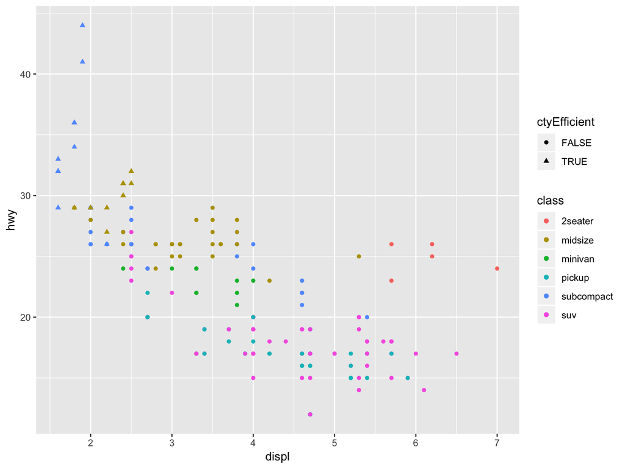

```r
mpg %>%
  filter(class != "compact") %>%
  mutate(ctyEfficient = cty>20) %>%
  select(displ, hwy, class, ctyEfficient) %>%
  ggplot() +
  aes(x=displ, y=hwy, color=class, shape = ctyEfficient) +
  geom_point()
```

# references

- http://genomicsclass.github.io/book/pages/dplyr_tutorial.html
- https://uc-r.github.io/tidyr
- http://stat545.com/bit001_dplyr-cheatsheet.html#inner_joinsuperheroes-publishers